# **Über diese App**

Diese Shiny-App dient zur Auswertung von qPCR-Daten. Die Daten können in einer Datei oder in zwei separaten Dateien vorliegen. Liegen die Daten in zwei Dateien vor, können sie (für passende Probenummern) zusammengeführt werden.

### **Dateninput**

Dateien müssen im folgenden Verzeichnis gespeichert und von dort eingelesen werden:  
📂 **O:/Abteilung Humanmedizin (AHM)/Referat 32/32_6/qPCR_CSVs/**

### **Erstellung der CSV-Dateien**

Die Rohdaten der Bio-Rad qPCR befinden sich in:  
📂 **H:\Analysenetz\NETLDAS0004_01\PCR Ergebnisse**  
📂 **H:\Analysenetz\NETLDAS0004\PCR Läufe\PCR Ergebnisse**

Um die Daten zu exportieren:

1. Öffnen Sie die Dateien **nacheinander** mit der **Bio-Rad CFX Manager Software**.
2. Wählen Sie **“Export > Custom Export…”**
3. Konfigurieren Sie den Export entsprechend (Einstellungen wie abgebildet sollten Standard sein).
4. Speicher unter 📂 **O:/Abteilung Humanmedizin (AHM)/Referat 32/32_6/qPCR_CSVs/**

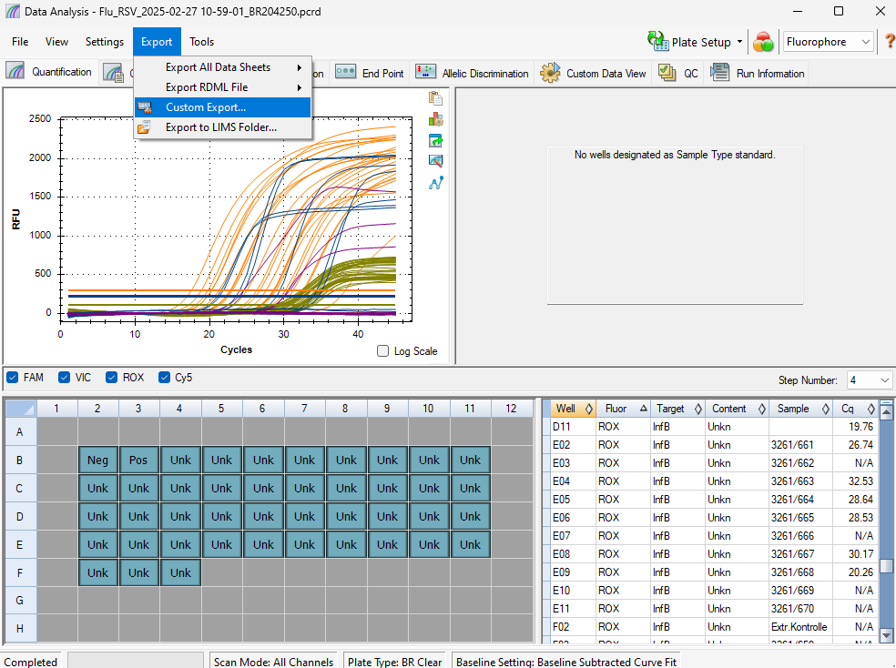

Figure 1

Then leave all the settings at default values. This should look like this:

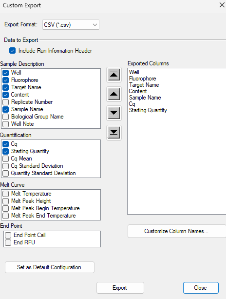

### **Anleitung zur Nutzung**

### 🔬 **qPCR-Datenanalyse – Anleitung**

🔹 **So gehen Sie vor:**

🔷 **1.** Entscheiden Sie, ob Sie **eine oder zwei Dateien** hochladen möchten.  
*Zwei Dateien mit übereinstimmenden Probennamen werden zusammengeführt.*

🔷 **2.** Wählen Sie Ihre **qPCR-Ergebnisdateien** aus und laden Sie sie hoch (**eine oder zwei Dateien**).

🔷 **3.** Drücken Sie **“Daten verarbeiten”**.

🔷 **4.** Sehen Sie sich die Ergebnisse an und werten Sie die **qPCR-Daten** aus.

📌 **Hinweis:** Falls Sie Fragen haben oder Unterstützung benötigen, wenden Sie sich bitte an die **Prüfleitung (Heitlinger, Holländer)**. 🚀